# Flight Tracking and Weather

April 30, 2018

## Introduction

For this project I choose to analyze flights from six different cities to see if the weather directly impacts the delay time. My data for this project came from developer.flightstats.com, and I uesd both Flight Status & Track by Airport (departures), and Weather APIs. The flight tracking information goes from about 9:45 am to 3:45 pm on Wednesday, April 25th.

## Airports Used

Here are the airports I used. I selected them based off of their weather on April 25th, as I wanted to have a variety of temperatures and conditions. I used USA Today National Weather map to make my selections.

[figure not shown]

## Using the Afternoon Forecast

The first data I used to examine the weather conditions was the afternoon forecast. Using text mining, I ranked each city's forecast as positive and negative. I then graphed the data, subtracting the negative words. I included a scaled down version of the delay minutes, to show how severe the average delay time was in contrast to the weather. The bars represent the weather, and points represent avg. delay.

## Good Forecast Data by City

| word | city |
| --- | --- |
| 10 | BOS |
| 10 | CLE |
| 10 | DFW |
| 10 | SFO |
| 15 | BOS |
| 15 | DFW |
| 15 | DFW |
| steady | BOS |
| steady | DFW |
| 60s | DFW |
| 60s | SFO |
| 5 | MIA |
| 80s | MIA |
| sunny | MIA |
| sunny | PDX |
| sunny | SFO |
| 80 | PDX |
| 85 | PDX |
| light | PDX |
| upper | SFO |

These words have have been chosen from the weather forecasts to represent good weather. The numbers, e.g. 5 and 10 represent wind speed, and are included because these are low wind speeds.

[figure not shown]

Good weather

## Bad Forecast Data by City

| word | city |
| --- | --- |
| 100 | BOS |
| 30 | BOS |
| 50s | BOS |
| 50s | CLE |
| cooler | BOS |
| cooler | DFW |
| fog | BOS |
| fog | CLE |
| lower | BOS |
| lower | DFW |
| patchy | BOS |
| patchy | CLE |
| rain | BOS |
| rain | BOS |
| rain | CLE |
| rain | DFW |
| rain | DFW |
| rain | DFW |
| 20 | CLE |
| 20 | CLE |
| 20 | DFW |
| 20 | SFO |
| cloudy | CLE |
| cloudy | DFW |
| thunderstorms | DFW |

These words have have been chosen from the weather forecasts to represent bad weather. The numbers, e.g. 20 and 30 represent wind speed, and are included because these are high wind speeds.

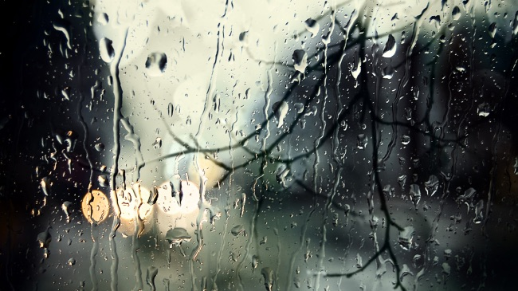

## Graph of Afternoon Weather Condition and Delay Time

The delay times have been scaled to appropriately fit the weather data. The bars represent the weather conditions and the points represent the delays.

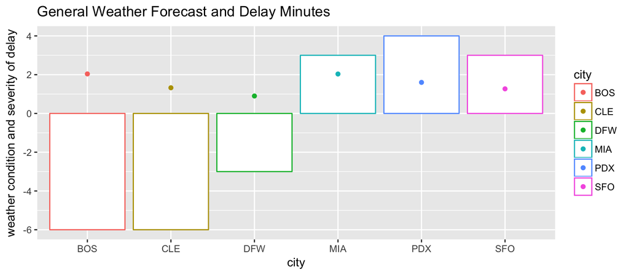

## Graph of Week-Long Weather Condition and Delay Time

The delay times have been scaled to appropriately fit the weather data. The bars represent the weather conditions and the points represent the delays.

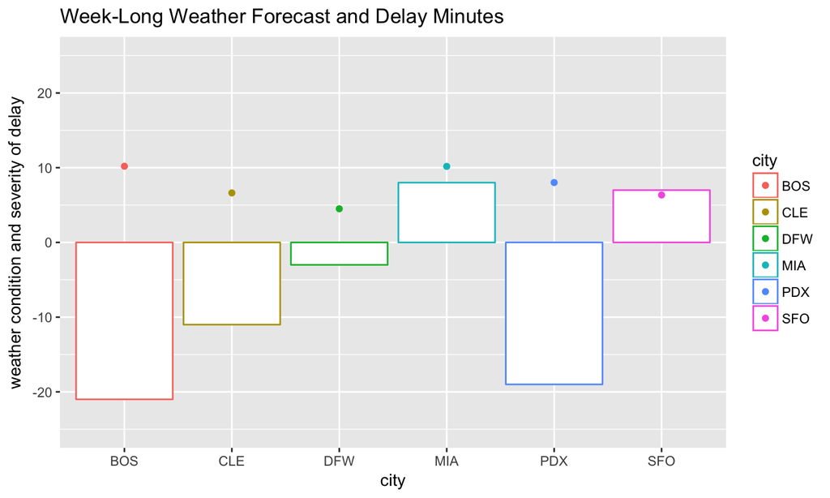

## Conclusions

## Data

The limitations of my data was that the forecasts are relatively short, and that means there are not many words in each. Ranking the weather based on these words is therefore not completely accurate.

Since the flight tracks only give you a 6 hour window, I did not have a lot of data to use for flight delays and this may have made the delay data inaccurate.

## Timing

I felt the timing was not ideal for this particular project, because in America in April there is very little severe weather, so the biggest hinderances will likely be rain and fog, whereas in January or February you may find more issues with snow, ice, and freezing temperatures.